# Heart Failure Prediction Dataset

### ExerciseAngina

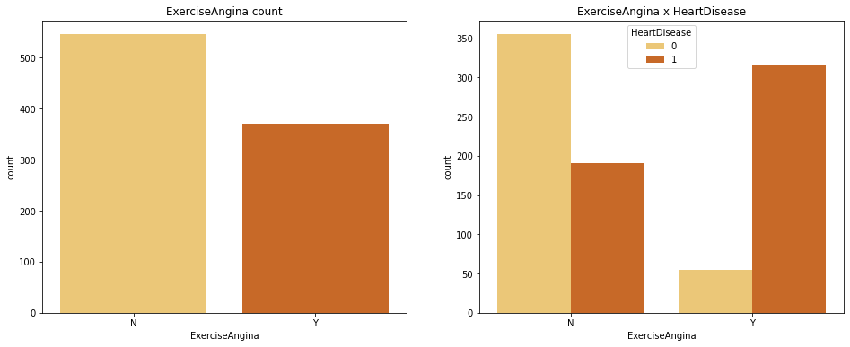

```python
fig, ax = plt.subplots(1, 2, figsize=(16, 6))
sns.countplot(data = df, x = 'ExerciseAngina', palette = pal, ax=ax[0]).set_title('ExerciseAngina count')
sns.countplot(data = df, x = 'ExerciseAngina', hue = 'HeartDisease', palette = pal, ax=ax[1]).set_title('ExerciseAngina x HeartDisease')
fig.show()
```

```python
ct = pd.crosstab(df['ExerciseAngina'], df['HeartDisease'], margins = True).style.background_gradient(cmap = pal)
ct
```

| HeartDisease ExerciseAngina | 0 | 1 | All |
| --- | --- | --- | --- |
| N | 355 | 191 | 546 |
| Y | 55 | 316 | 371 |
| All | 410 | 507 | 917 |

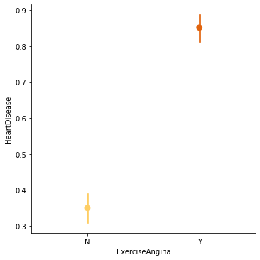

| ExerciseAngina | HeartDisease |
| --- | --- |
| N | 0.349817 |
| Y | 0.851752 |

```python
sns.factorplot(data = df, x = 'ExerciseAngina', y = 'HeartDisease', palette = pal)
plt.show()

df[['ExerciseAngina', 'HeartDisease']].groupby(['ExerciseAngina'], as_index = False).mean().style.hide_index()
```

**Pozorování**

- Pacienti s angínou vyvolanou cvičením mají více než dvojnásobné riziko srdeční nemoci (cca 85%) než zbytek pacientů (cca 35%).

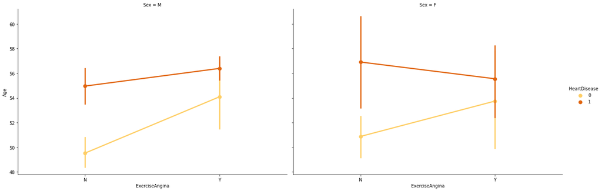

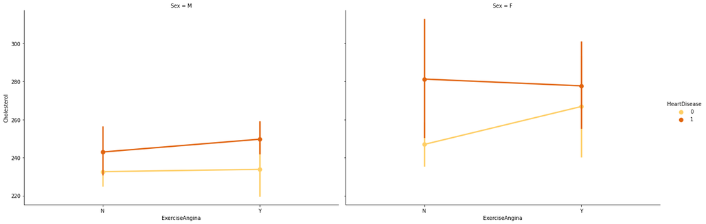

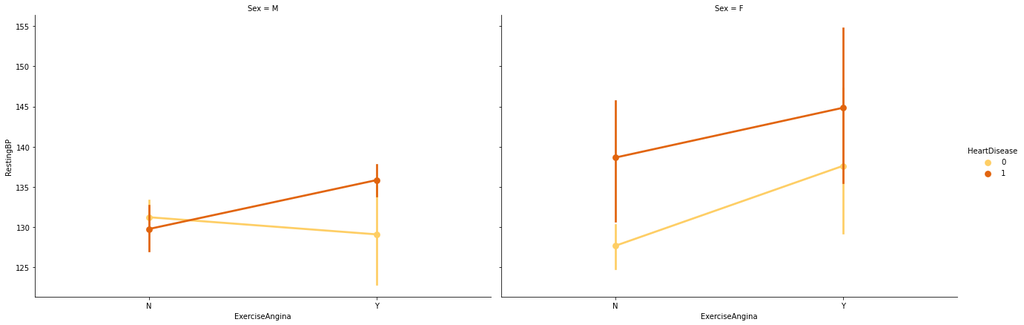

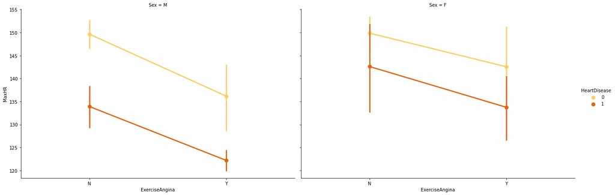

```python
sns.factorplot(data = df, x = 'ExerciseAngina', y = 'Age', hue = 'HeartDisease', col = 'Sex', palette = pal, size = 6, aspect = 1.5)
sns.factorplot(data = df, x = 'ExerciseAngina', y = 'Cholesterol', hue = 'HeartDisease', col = 'Sex', palette = pal, size = 6, aspect = 1.5)
sns.factorplot(data = df, x = 'ExerciseAngina', y = 'RestingBP', hue = 'HeartDisease', col = 'Sex', palette = pal, size = 6, aspect = 1.5)
sns.factorplot(data = df, x = 'ExerciseAngina', y = 'MaxHR', hue = 'HeartDisease', col = 'Sex', palette = pal, size = 6, aspect = 1.5)
plt.show()
```

**Pozorování**

- Ženy se srdeční nemoci a angínou vyvolanou cvičením mají menší průměrný věk a cholesterol než ženy bez angíny vyvolané cvičením.

### Oldpeak

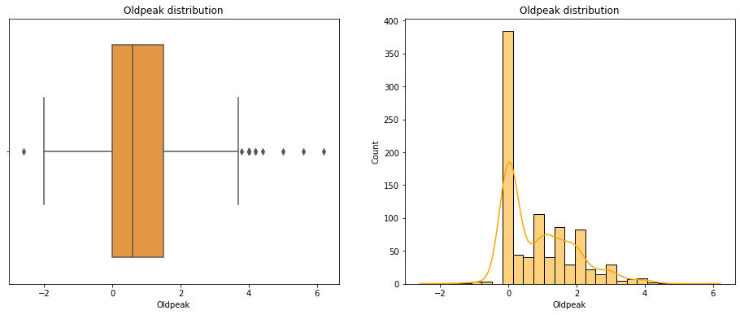

```python
fig, ax = plt.subplots(1, 2, figsize=(16, 6))
sns.boxplot(data = df, x = 'Oldpeak', palette = pal, ax=ax[0]).set_title('Oldpeak distribution')
sns.histplot(data = df, x = 'Oldpeak', kde = True, color = col, ax=ax[1]).set_title('Oldpeak distribution')
fig.show()
```

```python
print("Skewness: %f" % df['Oldpeak'].skew())
print("Kurtosis: %f" % df['Oldpeak'].kurt())
```

```
Skewness: 1.024545
Kurtosis: 1.203978
```

**Pozorování**

- Data obsahují odlehlá pozorování.
- Distrubuce nemá normální rozdělení.

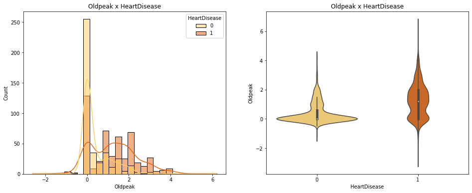

```python
fig, ax = plt.subplots(1, 2, figsize=(16, 6))
sns.histplot(data = df, hue = 'HeartDisease', x = 'Oldpeak', kde = True, palette = pal, ax=ax[0]).set_title('Oldpeak x HeartDisease')
sns.violinplot(data = df, x = 'HeartDisease', y = 'Oldpeak', palette = pal, ax=ax[1]).set_title('Oldpeak x HeartDisease')
fig.show()
```

**Pozorování**

- Pacienti se srdeční nemocí mají v průměru lehce vyšší hodnotu "Oldpeak".
- Většina pacientů bez srdeční nemoci má hodnotu "Oldpeak" rovnu nule.

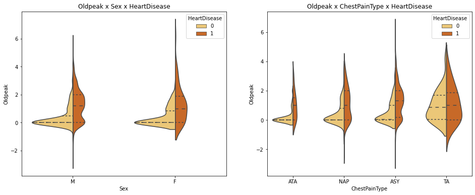

```python
fig, ax = plt.subplots(1, 2, figsize=(16, 6))
sns.violinplot(data = df, x = 'Sex', y = 'Oldpeak', hue = 'HeartDisease', palette = pal, size = 6, aspect = 1.5, split = True, inner = 'quart', ax=ax[0]).set_title('Oldpeak x Sex x HeartDisease')
sns.violinplot(data = df, x = 'ChestPainType', y = 'Oldpeak', hue = 'HeartDisease', palette = pal, size = 6, aspect = 1.5, split = True, inner = 'quart', ax=ax[1]).set_title('Oldpeak x ChestPainType x HeartDisease')
fig.show()
```

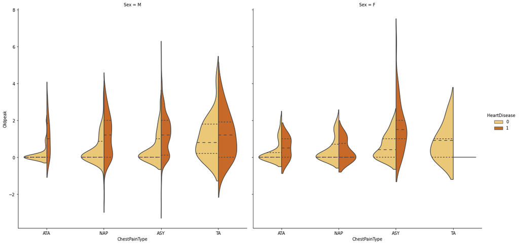

```python
sns.catplot(data = df, x = 'ChestPainType', y = 'Oldpeak', hue = 'HeartDisease', col = 'Sex', kind="violin", split=True, inner = 'quart', palette = pal, size = 8)
fig.show()
```